# **Problem Statement**

## Business Context

Renewable energy sources play an increasingly important role in the global energy mix, as the effort to reduce the environmental impact of energy production increases.

Out of all the renewable energy alternatives, wind energy is one of the most developed technologies worldwide. The U.S Department of Energy has put together a guide to achieving operational efficiency using predictive maintenance practices.

Predictive maintenance uses sensor information and analysis methods to measure and predict degradation and future component capability. The idea behind predictive maintenance is that failure patterns are predictable and if component failure can be predicted accurately and the component is replaced before it fails, the costs of operation and maintenance will be much lower.

The sensors fitted across different machines involved in the process of energy generation collect data related to various environmental factors (temperature, humidity, wind speed, etc.) and additional features related to various parts of the wind turbine (gearbox, tower, blades, break, etc.).

## Objective

“ReneWind” is a company working on improving the machinery/processes involved in the production of wind energy using machine learning and has collected data of generator failure of wind turbines using sensors. They have shared a ciphered version of the data, as the data collected through sensors is confidential (the type of data collected varies with companies). Data has 40 predictors, 20000 observations in the training set and 5000 in the test set.

The objective is to build various classification models, tune them, and find the best one that will help identify failures so that the generators could be repaired before failing/breaking to reduce the overall maintenance cost. The nature of predictions made by the classification model will translate as follows:

- True positives (TP) are failures correctly predicted by the model. These will result in repairing costs.
- False negatives (FN) are real failures where there is no detection by the model. These will result in replacement costs.
- False positives (FP) are detections where there is no failure. These will result in inspection costs.

It is given that the cost of repairing a generator is much less than the cost of replacing it, and the cost of inspection is less than the cost of repair.

“1” in the target variables should be considered as “failure” and “0” represents “No failure”.

## Data Description

The data provided is a transformed version of the original data which was collected using sensors.

- Train.csv - To be used for training and tuning of models.
- Test.csv - To be used only for testing the performance of the final best model.

Both the datasets consist of 40 predictor variables and 1 target variable.

# **Installing and Importing the necessary libraries**

```python
# Installing the libraries with the specified version
!pip install --no-deps tensorflow==2.18.0 scikit-learn==1.3.2 matplotlib===3.8.3 seaborn==0.13.2 numpy==1.26.4 pandas==2.2.2 -q --user --no-warn-script-location
```

**Note**:

- After running the above cell, kindly restart the runtime (for Google Colab) or notebook kernel (for Jupyter Notebook), and run all cells sequentially from the next cell.
- On executing the above line of code, you might see a warning regarding package dependencies. This error message can be ignored as the above code ensures that all necessary libraries and their dependencies are maintained to successfully execute the code in **this notebook**.

# **Loading the Data**

```python
import pandas as pd

train = pd.read_csv("Train.csv")
test = pd.read_csv("Test.csv")
```

# **Data Overview**

```python
print("Train shape:", train.shape)
print("Test shape:", test.shape)
```

```
Train shape: (20000, 41)
Test shape: (5000, 41)
```

```python
display(train.head())
```

|  | V1 | V2 | V3 | V4 | V5 | V6 | V7 | V8 | V9 | V10 | ... | V32 | V33 | V34 | V35 | V36 | V37 | V38 | V39 | V40 | Target |
| --- | --- | --- | --- | --- | --- | --- | --- | --- | --- | --- | --- | --- | --- | --- | --- | --- | --- | --- | --- | --- | --- |
| 0 | -4.464606 | -4.679129 | 3.101546 | 0.506130 | -0.221083 | -2.032511 | -2.910870 | 0.050714 | -1.522351 | 3.761892 | ... | 3.059700 | -1.690440 | 2.846296 | 2.235198 | 6.667486 | 0.443809 | -2.369169 | 2.950578 | -3.480324 | 0 |
| 1 | 3.365912 | 3.653381 | 0.909671 | -1.367528 | 0.332016 | 2.358938 | 0.732600 | -4.332135 | 0.565695 | -0.101080 | ... | -1.795474 | 3.032780 | -2.467514 | 1.894599 | -2.297780 | -1.731048 | 5.908837 | -0.386345 | 0.616242 | 0 |
| 2 | -3.831843 | -5.824444 | 0.634031 | -2.418815 | -1.773827 | 1.016824 | -2.098941 | -3.173204 | -2.081860 | 5.392621 | ... | -0.257101 | 0.803550 | 4.086219 | 2.292138 | 5.360850 | 0.351993 | 2.940021 | 3.839160 | -4.309402 | 0 |
| 3 | 1.618098 | 1.888342 | 7.046143 | -1.147285 | 0.083080 | -1.529780 | 0.207309 | -2.493629 | 0.344926 | 2.118578 | ... | -3.584425 | -2.577474 | 1.363769 | 0.622714 | 5.550100 | -1.526796 | 0.138853 | 3.101430 | -1.277378 | 0 |
| 4 | -0.111440 | 3.872488 | -3.758361 | -2.982897 | 3.792714 | 0.544960 | 0.205433 | 4.848994 | -1.854920 | -6.220023 | ... | 8.265896 | 6.629213 | -10.068689 | 1.222987 | -3.229763 | 1.686909 | -2.163896 | -3.644622 | 6.510338 | 0 |

5 rows × 41 columns

```python
print("\nInfo:")
print(train.info())
```

```
Info:
<class 'pandas.core.frame.DataFrame'>
RangeIndex: 20000 entries, 0 to 19999
Data columns (total 41 columns):
 #   Column  Non-Null Count  Dtype
---  ------  --------------  -----
 0   V1      19982 non-null  float64
 1   V2      19982 non-null  float64
 2   V3      20000 non-null  float64
 3   V4      20000 non-null  float64
 4   V5      20000 non-null  float64
 5   V6      20000 non-null  float64
 6   V7      20000 non-null  float64
 7   V8      20000 non-null  float64
 8   V9      20000 non-null  float64
```

[output cut: 35 more lines]

```python
#Checking missing values
print("\nMissing values per column:")
print(train.isnull().sum().sort_values(ascending=False).head(10))

# Check duplicates
print("\nDuplicate rows:", train.duplicated().sum())
```

```
Missing values per column:
V1     18
V2     18
V40     0
V30     0
V23     0
V24     0
V25     0
V26     0
V27     0
V28     0
dtype: int64

Duplicate rows: 0
```

```python
# Target distribution
print("\nTarget distribution:")
print(train['Target'].value_counts(normalize=True)*100)
```

```
Target distribution:
Target
0    94.45
1     5.55
Name: proportion, dtype: float64
```

## Data Overview

# **Exploratory Data Analysis**

```python
import matplotlib.pyplot as plt
```

## Univariate analysis

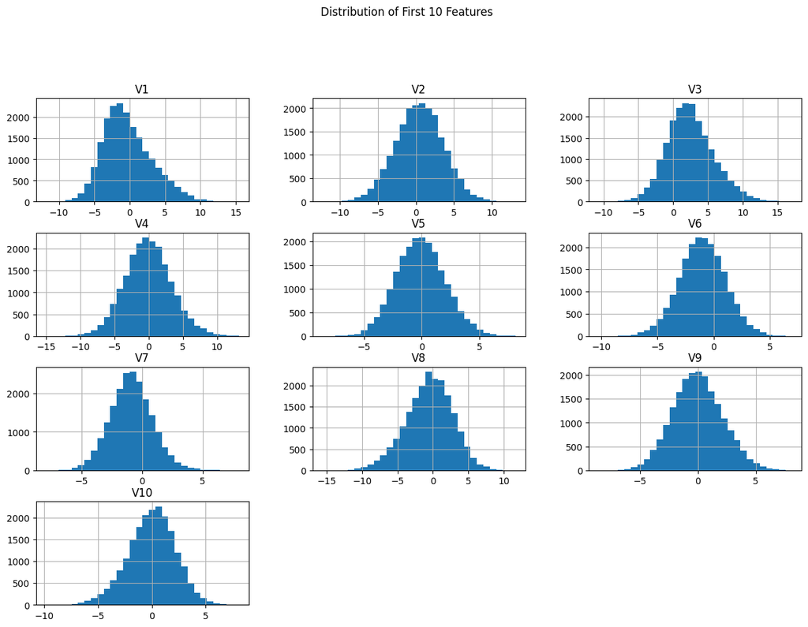

```python
train.drop(columns=['Target']).iloc[:, :10].hist(bins=30, figsize=(15,10))
plt.suptitle("Distribution of First 10 Features", y=1.02)
plt.show()
```

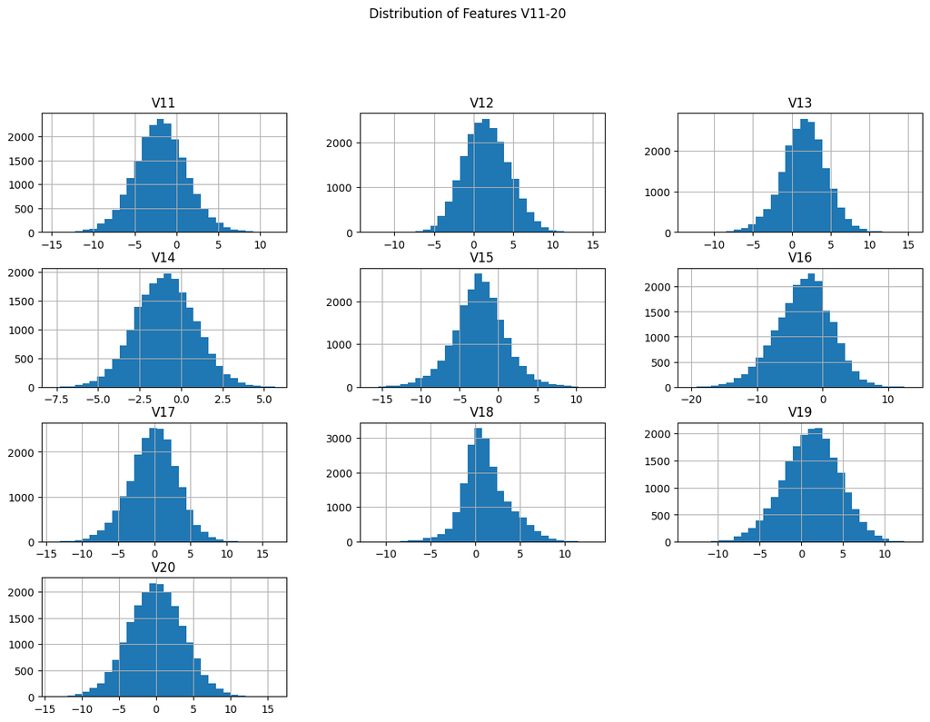

```python
train.drop(columns=['Target']).iloc[:, 10:20].hist(bins=30, figsize=(15,10))
plt.suptitle("Distribution of Features V11-20", y=1.02)
plt.show()
```

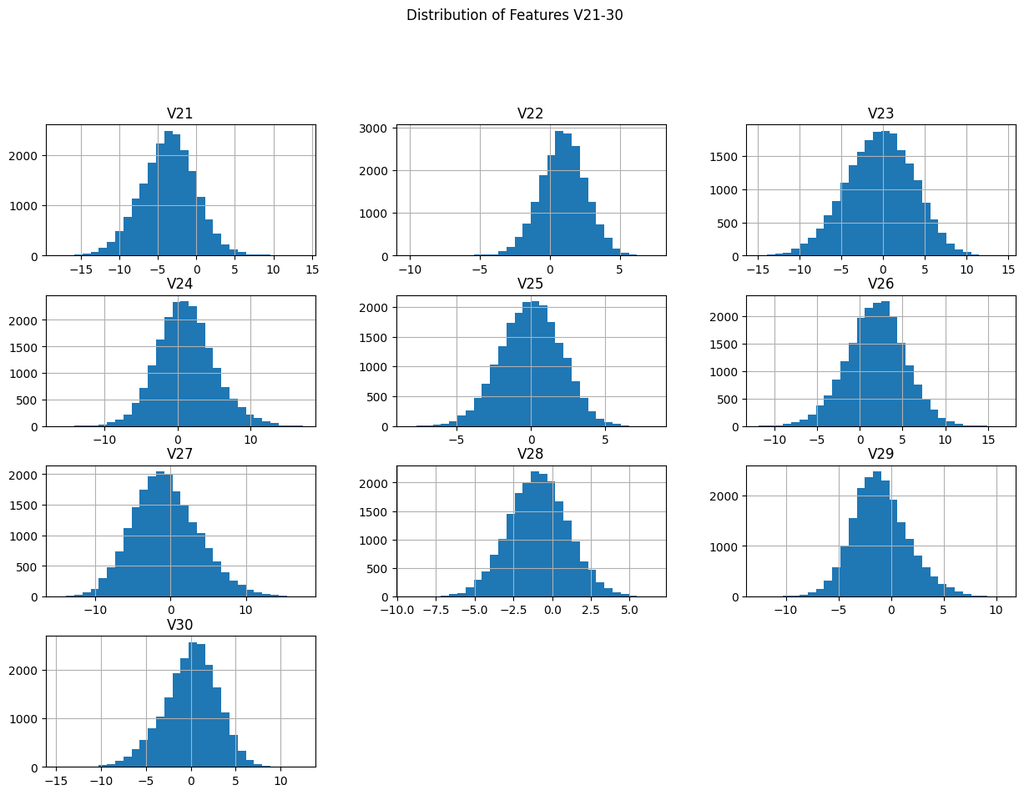

```python
train.drop(columns=['Target']).iloc[:, 20:30].hist(bins=30, figsize=(15,10))
plt.suptitle("Distribution of Features V21-30", y=1.02)
plt.show()
```

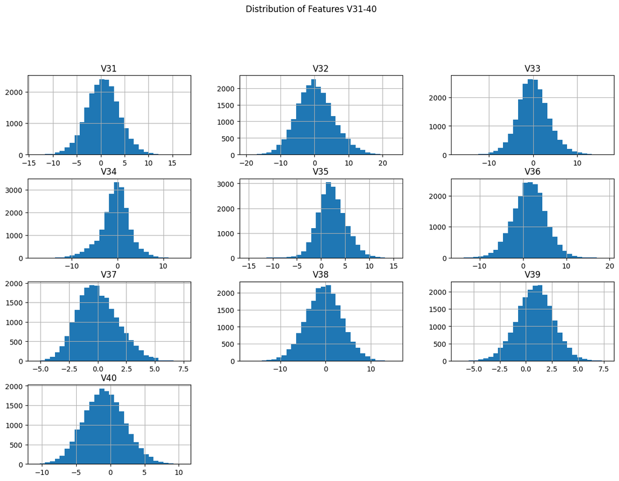

```python
train.drop(columns=['Target']).iloc[:, 30:40].hist(bins=30, figsize=(15,10))
plt.suptitle("Distribution of Features V31-40", y=1.02)
plt.show()
```

## Univariate Analysis Observations

- Most features follow an **approximately symmetric bell-shaped distribution** (close to normal).
- A few variables show **slight skewness** (e.g., V1, V8, V32... etc).
- Some variables have **longer tails/outliers** on either side (e.g., V4, V21, V27.. etc).
- Feature ranges differ slightly (some spread between -15 to 15, others narrower like -5 to 5).
- Overall distributions look stable as no extreme anomalies are spotted.

## Bivariate Analysis

```python
import seaborn as sns
```

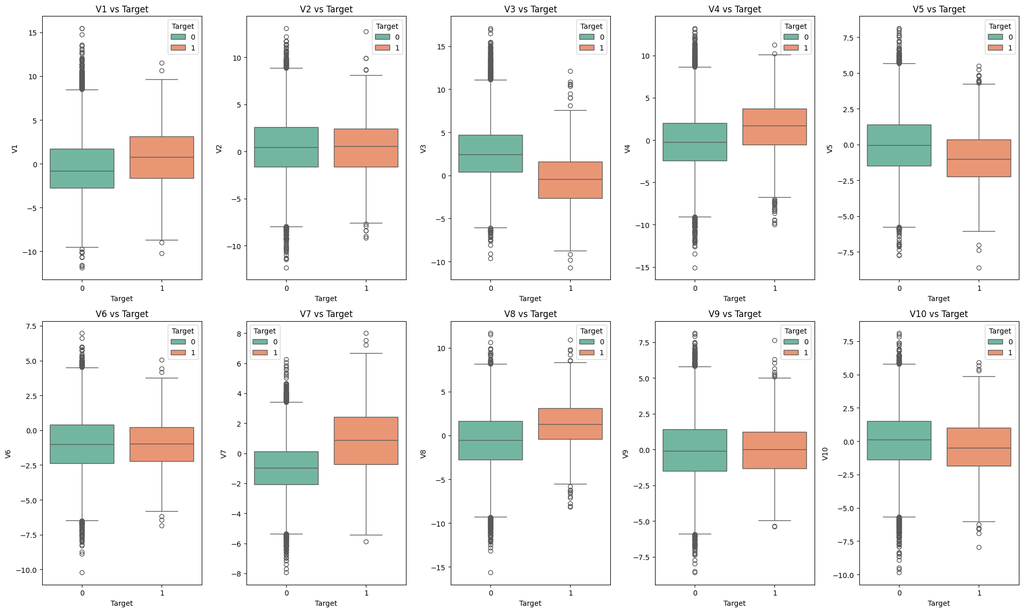

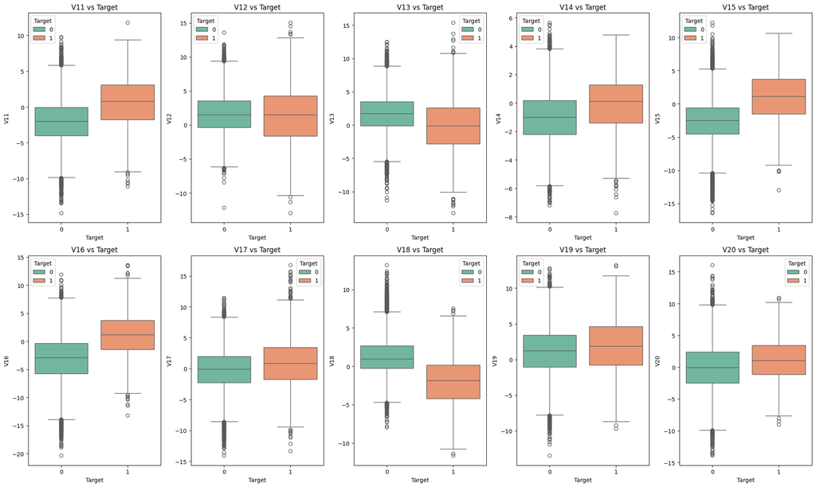

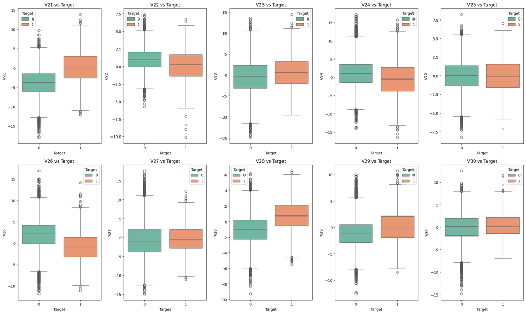

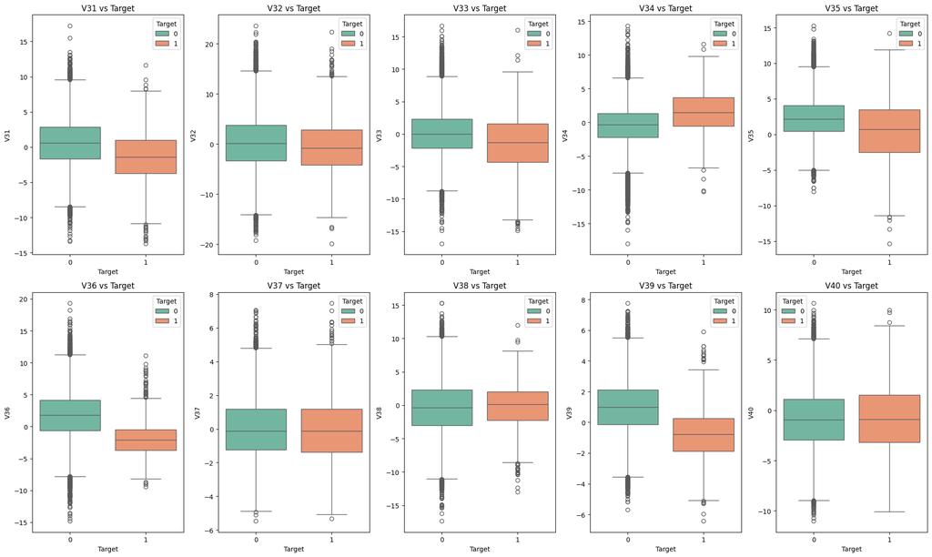

```python
features = train.drop(columns=["Target"]).columns

for i in range(0, len(features), 10):
    plt.figure(figsize=(20, 12))
    for j, col in enumerate(features[i:i+10], 1):
        plt.subplot(2, 5, j)
        sns.boxplot(x="Target", y=col, data=train, palette="Set2", hue="Target")
        plt.title(f"{col} vs Target")
    plt.tight_layout()
    plt.show()
```

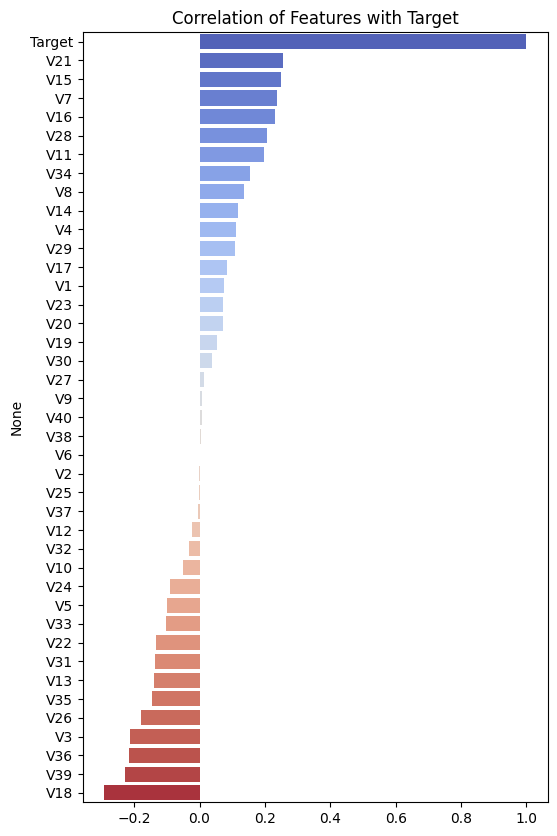

```python
target_corr = train.corr()["Target"].sort_values(ascending=False)

plt.figure(figsize=(6,10))
sns.barplot(y=target_corr.index, x=target_corr.values, palette="coolwarm", hue=target_corr.index)
plt.title("Correlation of Features with Target")
plt.show()
```

## Bivariate Analysis Observations

# **Data Preprocessing**

```python
# From earlier analysis we know that 2 columns have 18 missing values, Let's fix them using median imputation

from sklearn.impute import SimpleImputer

imputer = SimpleImputer(strategy="median")
train_imputed = train.copy()
train_imputed.iloc[:, :-1] = imputer.fit_transform(train.iloc[:, :-1])
```

```python
# Checking if missing value problem has been solved
print(train_imputed.isnull().sum().sort_values(ascending=False).head(10))
```

```
V1     0
V22    0
V24    0
V25    0
V26    0
V27    0
V28    0
V29    0
V30    0
V31    0
dtype: int64
```

```python
# As features are continuous with varying ranges, we will use StandardScaler for scaling
# This will ensure each feature has mean 0 and standard deviation 1

from sklearn.preprocessing import StandardScaler

scaler = StandardScaler()
X = train_imputed.drop(columns=["Target"])
y = train_imputed["Target"]

X_scaled = scaler.fit_transform(X)
```

```python
# Now, lets split the data into training and validation sets - We will use test.csv only for final evaluation

from sklearn.model_selection import train_test_split
X_train, X_val, y_train, y_val = train_test_split(X_scaled, y, test_size=0.2,  stratify=y)
```

# **Model Building**

## Model Evaluation Criterion

## Error Cost Trade-off

- **False Negatives (FN):** The most costly error, since missing a failure leads to full generator replacement.
- **False Positives (FP):** Lower cost, only leads to additional inspection.
- **True Positives (TP):** Lead to repairs, which are cheaper than replacements.

Hence, we will priortize **Recall** as the main evaluation criterion, while using F1 as a secondary evaluation metrics.

## Initial Model Building (Model 0)

- Let's start with a neural network consisting of
  - just one hidden layer
  - activation function of ReLU
  - SGD as the optimizer

```python
import tensorflow as tf
from tensorflow.keras.models import Sequential
from tensorflow.keras.layers import Dense
from tensorflow.keras.optimizers import SGD
```

```python
model = Sequential([
    Dense(32, activation='relu', input_shape=(X_train.shape[1],)),
    Dense(1, activation='sigmoid')
])
```

```python
optimizer = SGD(learning_rate=0.01, momentum=0.9)
model.compile(optimizer=optimizer,
              loss='binary_crossentropy',
              metrics=['accuracy',
                       tf.keras.metrics.Recall(name='recall'),
                       tf.keras.metrics.F1Score(name='f1_score', average='micro', threshold=0.5)])
```

```python
history = model.fit(X_train, y_train,
                    validation_data=(X_val, y_val),
                    epochs=20, batch_size=32, verbose=1)
```

```
  1/500 ━━━━━━━━━━━━━━━━━━━━ 5:29 660ms/step - accuracy: 0.6562 - f1_score: 0.0000e+00 - loss: 0.5658 - recall: 0.0000e+00
```

```
 41/500 ━━━━━━━━━━━━━━━━━━━━ 0s 1ms/step - accuracy: 0.8645 - f1_score: 0.0307 - loss: 0.4193 - recall: 0.0363
```

```
 87/500 ━━━━━━━━━━━━━━━━━━━━ 0s 1ms/step - accuracy: 0.8935 - f1_score: 0.0424 - loss: 0.3487 - recall: 0.0351
```

```
132/500 ━━━━━━━━━━━━━━━━━━━━ 0s 1ms/step - accuracy: 0.9074 - f1_score: 0.0662 - loss: 0.3080 - recall: 0.0468
```

```
177/500 ━━━━━━━━━━━━━━━━━━━━ 0s 1ms/step - accuracy: 0.9163 - f1_score: 0.1036 - loss: 0.2809 - recall: 0.0691
```

```
219/500 ━━━━━━━━━━━━━━━━━━━━ 0s 1ms/step - accuracy: 0.9221 - f1_score: 0.1472 - loss: 0.2631 - recall: 0.0977
```

```
264/500 ━━━━━━━━━━━━━━━━━━━━ 0s 1ms/step - accuracy: 0.9269 - f1_score: 0.1863 - loss: 0.2482 - recall: 0.1246
```

```
309/500 ━━━━━━━━━━━━━━━━━━━━ 0s 1ms/step - accuracy: 0.9308 - f1_score: 0.2180 - loss: 0.2360 - recall: 0.1468
```

```
354/500 ━━━━━━━━━━━━━━━━━━━━ 0s 1ms/step - accuracy: 0.9340 - f1_score: 0.2458 - loss: 0.2259 - recall: 0.1668
```

```
400/500 ━━━━━━━━━━━━━━━━━━━━ 0s 1ms/step - accuracy: 0.9368 - f1_score: 0.2714 - loss: 0.2173 - recall: 0.1858
```

```
445/500 ━━━━━━━━━━━━━━━━━━━━ 0s 1ms/step - accuracy: 0.9390 - f1_score: 0.2942 - loss: 0.2100 - recall: 0.2032
```

```
490/500 ━━━━━━━━━━━━━━━━━━━━ 0s 1ms/step - accuracy: 0.9411 - f1_score: 0.3153 - loss: 0.2036 - recall: 0.2198
```

```
500/500 ━━━━━━━━━━━━━━━━━━━━ 2s 2ms/step - accuracy: 0.9622 - f1_score: 0.5389 - loss: 0.1365 - recall: 0.3975 - val_accuracy: 0.9735 - val_f1_score: 0.6971 - val_loss: 0.0903 - val_recall: 0.5495
```

```
  1/500 ━━━━━━━━━━━━━━━━━━━━ 11s 24ms/step - accuracy: 0.9688 - f1_score: 0.0000e+00 - loss: 0.2753 - recall: 0.0000e+00
```

```
 46/500 ━━━━━━━━━━━━━━━━━━━━ 0s 1ms/step - accuracy: 0.9828 - f1_score: 0.7727 - loss: 0.0961 - recall: 0.6548
```

```
 92/500 ━━━━━━━━━━━━━━━━━━━━ 0s 1ms/step - accuracy: 0.9809 - f1_score: 0.7766 - loss: 0.0931 - recall: 0.6536
```

```
138/500 ━━━━━━━━━━━━━━━━━━━━ 0s 1ms/step - accuracy: 0.9797 - f1_score: 0.7701 - loss: 0.0933 - recall: 0.6444
```

```
186/500 ━━━━━━━━━━━━━━━━━━━━ 0s 1ms/step - accuracy: 0.9788 - f1_score: 0.7620 - loss: 0.0942 - recall: 0.6338
```

```
227/500 ━━━━━━━━━━━━━━━━━━━━ 0s 1ms/step - accuracy: 0.9785 - f1_score: 0.7597 - loss: 0.0940 - recall: 0.6309
```

```
271/500 ━━━━━━━━━━━━━━━━━━━━ 0s 1ms/step - accuracy: 0.9784 - f1_score: 0.7586 - loss: 0.0934 - recall: 0.6293
```

```
317/500 ━━━━━━━━━━━━━━━━━━━━ 0s 1ms/step - accuracy: 0.9782 - f1_score: 0.7578 - loss: 0.0928 - recall: 0.6282
```

```
363/500 ━━━━━━━━━━━━━━━━━━━━ 0s 1ms/step - accuracy: 0.9781 - f1_score: 0.7571 - loss: 0.0923 - recall: 0.6277
```

```
409/500 ━━━━━━━━━━━━━━━━━━━━ 0s 1ms/step - accuracy: 0.9781 - f1_score: 0.7578 - loss: 0.0917 - recall: 0.6290
```

```
455/500 ━━━━━━━━━━━━━━━━━━━━ 0s 1ms/step - accuracy: 0.9782 - f1_score: 0.7592 - loss: 0.0910 - recall: 0.6311
```

```
500/500 ━━━━━━━━━━━━━━━━━━━━ 1s 1ms/step - accuracy: 0.9793 - f1_score: 0.7790 - loss: 0.0836 - recall: 0.6588 - val_accuracy: 0.9808 - val_f1_score: 0.7913 - val_loss: 0.0733 - val_recall: 0.6577
```

```
  1/500 ━━━━━━━━━━━━━━━━━━━━ 11s 23ms/step - accuracy: 0.9688 - f1_score: 0.0000e+00 - loss: 0.0602 - recall: 0.0000e+00
```

```
 43/500 ━━━━━━━━━━━━━━━━━━━━ 0s 1ms/step - accuracy: 0.9856 - f1_score: 0.7814 - loss: 0.0457 - recall: 0.6669
```

```
 88/500 ━━━━━━━━━━━━━━━━━━━━ 0s 1ms/step - accuracy: 0.9860 - f1_score: 0.8132 - loss: 0.0487 - recall: 0.7016
```

```
134/500 ━━━━━━━━━━━━━━━━━━━━ 0s 1ms/step - accuracy: 0.9853 - f1_score: 0.8176 - loss: 0.0531 - recall: 0.7064
```

```
179/500 ━━━━━━━━━━━━━━━━━━━━ 0s 1ms/step - accuracy: 0.9847 - f1_score: 0.8177 - loss: 0.0570 - recall: 0.7065
```

```
225/500 ━━━━━━━━━━━━━━━━━━━━ 0s 1ms/step - accuracy: 0.9843 - f1_score: 0.8181 - loss: 0.0597 - recall: 0.7065
```

```
271/500 ━━━━━━━━━━━━━━━━━━━━ 0s 1ms/step - accuracy: 0.9841 - f1_score: 0.8194 - loss: 0.0617 - recall: 0.7078
```

```
315/500 ━━━━━━━━━━━━━━━━━━━━ 0s 1ms/step - accuracy: 0.9841 - f1_score: 0.8209 - loss: 0.0629 - recall: 0.7100
```

```
361/500 ━━━━━━━━━━━━━━━━━━━━ 0s 1ms/step - accuracy: 0.9841 - f1_score: 0.8227 - loss: 0.0636 - recall: 0.7127
```

```
406/500 ━━━━━━━━━━━━━━━━━━━━ 0s 1ms/step - accuracy: 0.9841 - f1_score: 0.8244 - loss: 0.0640 - recall: 0.7151
```

```
450/500 ━━━━━━━━━━━━━━━━━━━━ 0s 1ms/step - accuracy: 0.9842 - f1_score: 0.8258 - loss: 0.0645 - recall: 0.7172
```

```
495/500 ━━━━━━━━━━━━━━━━━━━━ 0s 1ms/step - accuracy: 0.9842 - f1_score: 0.8273 - loss: 0.0648 - recall: 0.7196
```

```
500/500 ━━━━━━━━━━━━━━━━━━━━ 1s 1ms/step - accuracy: 0.9844 - f1_score: 0.8411 - loss: 0.0701 - recall: 0.7421 - val_accuracy: 0.9852 - val_f1_score: 0.8483 - val_loss: 0.0637 - val_recall: 0.7432
```

```
  1/500 ━━━━━━━━━━━━━━━━━━━━ 11s 24ms/step - accuracy: 1.0000 - f1_score: 0.0000e+00 - loss: 0.0184 - recall: 0.0000e+00
```

```
 47/500 ━━━━━━━━━━━━━━━━━━━━ 0s 1ms/step - accuracy: 0.9885 - f1_score: 0.8433 - loss: 0.0612 - recall: 0.7697
```

```
 93/500 ━━━━━━━━━━━━━━━━━━━━ 0s 1ms/step - accuracy: 0.9874 - f1_score: 0.8531 - loss: 0.0627 - recall: 0.7743
```

```
139/500 ━━━━━━━━━━━━━━━━━━━━ 0s 1ms/step - accuracy: 0.9864 - f1_score: 0.8505 - loss: 0.0647 - recall: 0.7667
```

```
186/500 ━━━━━━━━━━━━━━━━━━━━ 0s 1ms/step - accuracy: 0.9860 - f1_score: 0.8505 - loss: 0.0658 - recall: 0.7637
```

```
232/500 ━━━━━━━━━━━━━━━━━━━━ 0s 1ms/step - accuracy: 0.9857 - f1_score: 0.8510 - loss: 0.0672 - recall: 0.7621
```

```
279/500 ━━━━━━━━━━━━━━━━━━━━ 0s 1ms/step - accuracy: 0.9857 - f1_score: 0.8526 - loss: 0.0677 - recall: 0.7629
```

```
325/500 ━━━━━━━━━━━━━━━━━━━━ 0s 1ms/step - accuracy: 0.9858 - f1_score: 0.8546 - loss: 0.0675 - recall: 0.7649
```

```
371/500 ━━━━━━━━━━━━━━━━━━━━ 0s 1ms/step - accuracy: 0.9860 - f1_score: 0.8563 - loss: 0.0669 - recall: 0.7666
```

```
417/500 ━━━━━━━━━━━━━━━━━━━━ 0s 1ms/step - accuracy: 0.9861 - f1_score: 0.8576 - loss: 0.0664 - recall: 0.7681
```

```
463/500 ━━━━━━━━━━━━━━━━━━━━ 0s 1ms/step - accuracy: 0.9862 - f1_score: 0.8588 - loss: 0.0661 - recall: 0.7695
```

```
500/500 ━━━━━━━━━━━━━━━━━━━━ 1s 1ms/step - accuracy: 0.9869 - f1_score: 0.8690 - loss: 0.0634 - recall: 0.7804 - val_accuracy: 0.9862 - val_f1_score: 0.8608 - val_loss: 0.0598 - val_recall: 0.7658
```

```
  1/500 ━━━━━━━━━━━━━━━━━━━━ 11s 23ms/step - accuracy: 1.0000 - f1_score: 1.0000 - loss: 0.0406 - recall: 1.0000
```

```
 48/500 ━━━━━━━━━━━━━━━━━━━━ 0s 1ms/step - accuracy: 0.9859 - f1_score: 0.8621 - loss: 0.0608 - recall: 0.8076
```

```
 94/500 ━━━━━━━━━━━━━━━━━━━━ 0s 1ms/step - accuracy: 0.9862 - f1_score: 0.8617 - loss: 0.0589 - recall: 0.7961
```

```
140/500 ━━━━━━━━━━━━━━━━━━━━ 0s 1ms/step - accuracy: 0.9864 - f1_score: 0.8611 - loss: 0.0584 - recall: 0.7886
```

```
187/500 ━━━━━━━━━━━━━━━━━━━━ 0s 1ms/step - accuracy: 0.9865 - f1_score: 0.8598 - loss: 0.0588 - recall: 0.7823
```

```
235/500 ━━━━━━━━━━━━━━━━━━━━ 0s 1ms/step - accuracy: 0.9865 - f1_score: 0.8593 - loss: 0.0594 - recall: 0.7799
```

```
281/500 ━━━━━━━━━━━━━━━━━━━━ 0s 1ms/step - accuracy: 0.9865 - f1_score: 0.8599 - loss: 0.0595 - recall: 0.7795
```

```
328/500 ━━━━━━━━━━━━━━━━━━━━ 0s 1ms/step - accuracy: 0.9865 - f1_score: 0.8608 - loss: 0.0599 - recall: 0.7798
```

```
374/500 ━━━━━━━━━━━━━━━━━━━━ 0s 1ms/step - accuracy: 0.9866 - f1_score: 0.8622 - loss: 0.0602 - recall: 0.7810
```

```
420/500 ━━━━━━━━━━━━━━━━━━━━ 0s 1ms/step - accuracy: 0.9866 - f1_score: 0.8631 - loss: 0.0604 - recall: 0.7817
```

```
467/500 ━━━━━━━━━━━━━━━━━━━━ 0s 1ms/step - accuracy: 0.9867 - f1_score: 0.8640 - loss: 0.0605 - recall: 0.7826
```

```
500/500 ━━━━━━━━━━━━━━━━━━━━ 1s 1ms/step - accuracy: 0.9876 - f1_score: 0.8766 - loss: 0.0603 - recall: 0.7962 - val_accuracy: 0.9875 - val_f1_score: 0.8750 - val_loss: 0.0564 - val_recall: 0.7883
```

```
  1/500 ━━━━━━━━━━━━━━━━━━━━ 10s 22ms/step - accuracy: 0.9688 - f1_score: 0.8571 - loss: 0.0657 - recall: 0.7500
```

```
 48/500 ━━━━━━━━━━━━━━━━━━━━ 0s 1ms/step - accuracy: 0.9786 - f1_score: 0.8529 - loss: 0.0950 - recall: 0.7558
```

```
 95/500 ━━━━━━━━━━━━━━━━━━━━ 0s 1ms/step - accuracy: 0.9817 - f1_score: 0.8544 - loss: 0.0825 - recall: 0.7569
```

```
140/500 ━━━━━━━━━━━━━━━━━━━━ 0s 1ms/step - accuracy: 0.9829 - f1_score: 0.8566 - loss: 0.0768 - recall: 0.7607
```

```
186/500 ━━━━━━━━━━━━━━━━━━━━ 0s 1ms/step - accuracy: 0.9840 - f1_score: 0.8602 - loss: 0.0724 - recall: 0.7661
```

```
227/500 ━━━━━━━━━━━━━━━━━━━━ 0s 1ms/step - accuracy: 0.9846 - f1_score: 0.8619 - loss: 0.0705 - recall: 0.7686
```

```
269/500 ━━━━━━━━━━━━━━━━━━━━ 0s 1ms/step - accuracy: 0.9850 - f1_score: 0.8645 - loss: 0.0690 - recall: 0.7723
```

```
312/500 ━━━━━━━━━━━━━━━━━━━━ 0s 1ms/step - accuracy: 0.9854 - f1_score: 0.8672 - loss: 0.0675 - recall: 0.7766
```

```
358/500 ━━━━━━━━━━━━━━━━━━━━ 0s 1ms/step - accuracy: 0.9857 - f1_score: 0.8692 - loss: 0.0663 - recall: 0.7801
```

```
390/500 ━━━━━━━━━━━━━━━━━━━━ 0s 1ms/step - accuracy: 0.9859 - f1_score: 0.8702 - loss: 0.0656 - recall: 0.7820
```

```
431/500 ━━━━━━━━━━━━━━━━━━━━ 0s 1ms/step - accuracy: 0.9861 - f1_score: 0.8713 - loss: 0.0648 - recall: 0.7840
```

```
477/500 ━━━━━━━━━━━━━━━━━━━━ 0s 1ms/step - accuracy: 0.9863 - f1_score: 0.8722 - loss: 0.0641 - recall: 0.7859
```

```
500/500 ━━━━━━━━━━━━━━━━━━━━ 1s 2ms/step - accuracy: 0.9879 - f1_score: 0.8804 - loss: 0.0577 - recall: 0.8041 - val_accuracy: 0.9852 - val_f1_score: 0.8483 - val_loss: 0.0571 - val_recall: 0.7432
```

```
  1/500 ━━━━━━━━━━━━━━━━━━━━ 11s 23ms/step - accuracy: 1.0000 - f1_score: 1.0000 - loss: 0.0268 - recall: 1.0000
```

```
 48/500 ━━━━━━━━━━━━━━━━━━━━ 0s 1ms/step - accuracy: 0.9892 - f1_score: 0.8945 - loss: 0.0531 - recall: 0.8189
```

```
 94/500 ━━━━━━━━━━━━━━━━━━━━ 0s 1ms/step - accuracy: 0.9892 - f1_score: 0.8962 - loss: 0.0528 - recall: 0.8241
```

```
139/500 ━━━━━━━━━━━━━━━━━━━━ 0s 1ms/step - accuracy: 0.9890 - f1_score: 0.8956 - loss: 0.0525 - recall: 0.8228
```

```
184/500 ━━━━━━━━━━━━━━━━━━━━ 0s 1ms/step - accuracy: 0.9891 - f1_score: 0.8950 - loss: 0.0519 - recall: 0.8220
```

```
231/500 ━━━━━━━━━━━━━━━━━━━━ 0s 1ms/step - accuracy: 0.9889 - f1_score: 0.8921 - loss: 0.0527 - recall: 0.8176
```

```
275/500 ━━━━━━━━━━━━━━━━━━━━ 0s 1ms/step - accuracy: 0.9888 - f1_score: 0.8908 - loss: 0.0531 - recall: 0.8155
```

```
305/500 ━━━━━━━━━━━━━━━━━━━━ 0s 1ms/step - accuracy: 0.9887 - f1_score: 0.8898 - loss: 0.0535 - recall: 0.8138
```

```
344/500 ━━━━━━━━━━━━━━━━━━━━ 0s 1ms/step - accuracy: 0.9885 - f1_score: 0.8884 - loss: 0.0542 - recall: 0.8119
```

```
390/500 ━━━━━━━━━━━━━━━━━━━━ 0s 1ms/step - accuracy: 0.9884 - f1_score: 0.8874 - loss: 0.0549 - recall: 0.8105
```

```
436/500 ━━━━━━━━━━━━━━━━━━━━ 0s 1ms/step - accuracy: 0.9883 - f1_score: 0.8866 - loss: 0.0552 - recall: 0.8097
```

```
482/500 ━━━━━━━━━━━━━━━━━━━━ 0s 1ms/step - accuracy: 0.9883 - f1_score: 0.8860 - loss: 0.0554 - recall: 0.8090
```

```
500/500 ━━━━━━━━━━━━━━━━━━━━ 1s 2ms/step - accuracy: 0.9881 - f1_score: 0.8822 - loss: 0.0562 - recall: 0.8052 - val_accuracy: 0.9877 - val_f1_score: 0.8784 - val_loss: 0.0548 - val_recall: 0.7973
```

```
  1/500 ━━━━━━━━━━━━━━━━━━━━ 11s 24ms/step - accuracy: 1.0000 - f1_score: 1.0000 - loss: 0.0201 - recall: 1.0000
```

```
 49/500 ━━━━━━━━━━━━━━━━━━━━ 0s 1ms/step - accuracy: 0.9868 - f1_score: 0.8978 - loss: 0.0727 - recall: 0.8514
```

```
 96/500 ━━━━━━━━━━━━━━━━━━━━ 0s 1ms/step - accuracy: 0.9864 - f1_score: 0.8876 - loss: 0.0663 - recall: 0.8283
```

```
143/500 ━━━━━━━━━━━━━━━━━━━━ 0s 1ms/step - accuracy: 0.9867 - f1_score: 0.8869 - loss: 0.0635 - recall: 0.8229
```

```
189/500 ━━━━━━━━━━━━━━━━━━━━ 0s 1ms/step - accuracy: 0.9870 - f1_score: 0.8873 - loss: 0.0614 - recall: 0.8209
```

```
236/500 ━━━━━━━━━━━━━━━━━━━━ 0s 1ms/step - accuracy: 0.9872 - f1_score: 0.8876 - loss: 0.0606 - recall: 0.8197
```

```
279/500 ━━━━━━━━━━━━━━━━━━━━ 0s 1ms/step - accuracy: 0.9874 - f1_score: 0.8882 - loss: 0.0598 - recall: 0.8194
```

```
325/500 ━━━━━━━━━━━━━━━━━━━━ 0s 1ms/step - accuracy: 0.9876 - f1_score: 0.8890 - loss: 0.0589 - recall: 0.8197
```

```
371/500 ━━━━━━━━━━━━━━━━━━━━ 0s 1ms/step - accuracy: 0.9877 - f1_score: 0.8889 - loss: 0.0583 - recall: 0.8191
```

```
417/500 ━━━━━━━━━━━━━━━━━━━━ 0s 1ms/step - accuracy: 0.9878 - f1_score: 0.8887 - loss: 0.0579 - recall: 0.8185
```

```
462/500 ━━━━━━━━━━━━━━━━━━━━ 0s 1ms/step - accuracy: 0.9879 - f1_score: 0.8888 - loss: 0.0575 - recall: 0.8183
```

```
500/500 ━━━━━━━━━━━━━━━━━━━━ 1s 1ms/step - accuracy: 0.9886 - f1_score: 0.8883 - loss: 0.0549 - recall: 0.8153 - val_accuracy: 0.9885 - val_f1_score: 0.8861 - val_loss: 0.0533 - val_recall: 0.8063
```

```
  1/500 ━━━━━━━━━━━━━━━━━━━━ 11s 23ms/step - accuracy: 1.0000 - f1_score: 1.0000 - loss: 0.0295 - recall: 1.0000
```

```
 47/500 ━━━━━━━━━━━━━━━━━━━━ 0s 1ms/step - accuracy: 0.9914 - f1_score: 0.9209 - loss: 0.0443 - recall: 0.8649
```

```
 94/500 ━━━━━━━━━━━━━━━━━━━━ 0s 1ms/step - accuracy: 0.9910 - f1_score: 0.9164 - loss: 0.0442 - recall: 0.8603
```

```
140/500 ━━━━━━━━━━━━━━━━━━━━ 0s 1ms/step - accuracy: 0.9913 - f1_score: 0.9172 - loss: 0.0433 - recall: 0.8612
```

```
182/500 ━━━━━━━━━━━━━━━━━━━━ 0s 1ms/step - accuracy: 0.9914 - f1_score: 0.9175 - loss: 0.0432 - recall: 0.8612
```

```
228/500 ━━━━━━━━━━━━━━━━━━━━ 0s 1ms/step - accuracy: 0.9912 - f1_score: 0.9156 - loss: 0.0436 - recall: 0.8582
```

```
268/500 ━━━━━━━━━━━━━━━━━━━━ 0s 1ms/step - accuracy: 0.9911 - f1_score: 0.9144 - loss: 0.0440 - recall: 0.8564
```

```
309/500 ━━━━━━━━━━━━━━━━━━━━ 0s 1ms/step - accuracy: 0.9910 - f1_score: 0.9125 - loss: 0.0446 - recall: 0.8536
```

```
355/500 ━━━━━━━━━━━━━━━━━━━━ 0s 1ms/step - accuracy: 0.9908 - f1_score: 0.9104 - loss: 0.0453 - recall: 0.8503
```

```
401/500 ━━━━━━━━━━━━━━━━━━━━ 0s 1ms/step - accuracy: 0.9906 - f1_score: 0.9087 - loss: 0.0460 - recall: 0.8477
```

```
447/500 ━━━━━━━━━━━━━━━━━━━━ 0s 1ms/step - accuracy: 0.9905 - f1_score: 0.9070 - loss: 0.0465 - recall: 0.8453
```

```
494/500 ━━━━━━━━━━━━━━━━━━━━ 0s 1ms/step - accuracy: 0.9903 - f1_score: 0.9054 - loss: 0.0471 - recall: 0.8429
```

```
500/500 ━━━━━━━━━━━━━━━━━━━━ 1s 1ms/step - accuracy: 0.9886 - f1_score: 0.8886 - loss: 0.0540 - recall: 0.8176 - val_accuracy: 0.9868 - val_f1_score: 0.8658 - val_loss: 0.0555 - val_recall: 0.7703
```

```
  1/500 ━━━━━━━━━━━━━━━━━━━━ 11s 22ms/step - accuracy: 1.0000 - f1_score: 1.0000 - loss: 0.0149 - recall: 1.0000
```

```
 47/500 ━━━━━━━━━━━━━━━━━━━━ 0s 1ms/step - accuracy: 0.9945 - f1_score: 0.9270 - loss: 0.0361 - recall: 0.8730
```

```
 93/500 ━━━━━━━━━━━━━━━━━━━━ 0s 1ms/step - accuracy: 0.9933 - f1_score: 0.9190 - loss: 0.0395 - recall: 0.8597
```

```
138/500 ━━━━━━━━━━━━━━━━━━━━ 0s 1ms/step - accuracy: 0.9926 - f1_score: 0.9159 - loss: 0.0419 - recall: 0.8559
```

```
184/500 ━━━━━━━━━━━━━━━━━━━━ 0s 1ms/step - accuracy: 0.9920 - f1_score: 0.9127 - loss: 0.0436 - recall: 0.8519
```

```
230/500 ━━━━━━━━━━━━━━━━━━━━ 0s 1ms/step - accuracy: 0.9917 - f1_score: 0.9106 - loss: 0.0448 - recall: 0.8495
```

```
276/500 ━━━━━━━━━━━━━━━━━━━━ 0s 1ms/step - accuracy: 0.9915 - f1_score: 0.9094 - loss: 0.0458 - recall: 0.8480
```

```
323/500 ━━━━━━━━━━━━━━━━━━━━ 0s 1ms/step - accuracy: 0.9913 - f1_score: 0.9084 - loss: 0.0467 - recall: 0.8465
```

```
369/500 ━━━━━━━━━━━━━━━━━━━━ 0s 1ms/step - accuracy: 0.9912 - f1_score: 0.9075 - loss: 0.0473 - recall: 0.8450
```

```
416/500 ━━━━━━━━━━━━━━━━━━━━ 0s 1ms/step - accuracy: 0.9910 - f1_score: 0.9065 - loss: 0.0479 - recall: 0.8433
```

```
462/500 ━━━━━━━━━━━━━━━━━━━━ 0s 1ms/step - accuracy: 0.9909 - f1_score: 0.9058 - loss: 0.0485 - recall: 0.8421
```

```
500/500 ━━━━━━━━━━━━━━━━━━━━ 1s 1ms/step - accuracy: 0.9898 - f1_score: 0.9001 - loss: 0.0535 - recall: 0.8322 - val_accuracy: 0.9893 - val_f1_score: 0.8938 - val_loss: 0.0511 - val_recall: 0.8153
```

```
  1/500 ━━━━━━━━━━━━━━━━━━━━ 12s 26ms/step - accuracy: 1.0000 - f1_score: 1.0000 - loss: 0.0116 - recall: 1.0000
```

```
 46/500 ━━━━━━━━━━━━━━━━━━━━ 0s 1ms/step - accuracy: 0.9913 - f1_score: 0.9108 - loss: 0.0459 - recall: 0.8453
```

```
 93/500 ━━━━━━━━━━━━━━━━━━━━ 0s 1ms/step - accuracy: 0.9894 - f1_score: 0.8874 - loss: 0.0523 - recall: 0.8104
```

```
138/500 ━━━━━━━━━━━━━━━━━━━━ 0s 1ms/step - accuracy: 0.9884 - f1_score: 0.8779 - loss: 0.0558 - recall: 0.7959
```

```
185/500 ━━━━━━━━━━━━━━━━━━━━ 0s 1ms/step - accuracy: 0.9882 - f1_score: 0.8768 - loss: 0.0564 - recall: 0.7943
```

```
231/500 ━━━━━━━━━━━━━━━━━━━━ 0s 1ms/step - accuracy: 0.9882 - f1_score: 0.8784 - loss: 0.0563 - recall: 0.7964
```

```
279/500 ━━━━━━━━━━━━━━━━━━━━ 0s 1ms/step - accuracy: 0.9884 - f1_score: 0.8806 - loss: 0.0557 - recall: 0.7999
```

```
327/500 ━━━━━━━━━━━━━━━━━━━━ 0s 1ms/step - accuracy: 0.9885 - f1_score: 0.8831 - loss: 0.0551 - recall: 0.8038
```

```
374/500 ━━━━━━━━━━━━━━━━━━━━ 0s 1ms/step - accuracy: 0.9886 - f1_score: 0.8852 - loss: 0.0546 - recall: 0.8071
```

```
420/500 ━━━━━━━━━━━━━━━━━━━━ 0s 1ms/step - accuracy: 0.9887 - f1_score: 0.8863 - loss: 0.0545 - recall: 0.8090
```

```
467/500 ━━━━━━━━━━━━━━━━━━━━ 0s 1ms/step - accuracy: 0.9888 - f1_score: 0.8871 - loss: 0.0544 - recall: 0.8102
```

```
500/500 ━━━━━━━━━━━━━━━━━━━━ 1s 1ms/step - accuracy: 0.9896 - f1_score: 0.8981 - loss: 0.0527 - recall: 0.8288 - val_accuracy: 0.9893 - val_f1_score: 0.8949 - val_loss: 0.0508 - val_recall: 0.8243
```

```
  1/500 ━━━━━━━━━━━━━━━━━━━━ 11s 24ms/step - accuracy: 0.9688 - f1_score: 0.0000e+00 - loss: 0.0338 - recall: 0.0000e+00
```

```
 47/500 ━━━━━━━━━━━━━━━━━━━━ 0s 1ms/step - accuracy: 0.9894 - f1_score: 0.8422 - loss: 0.0394 - recall: 0.7826
```

```
 93/500 ━━━━━━━━━━━━━━━━━━━━ 0s 1ms/step - accuracy: 0.9899 - f1_score: 0.8668 - loss: 0.0419 - recall: 0.8013
```

```
139/500 ━━━━━━━━━━━━━━━━━━━━ 0s 1ms/step - accuracy: 0.9900 - f1_score: 0.8765 - loss: 0.0443 - recall: 0.8081
```

```
186/500 ━━━━━━━━━━━━━━━━━━━━ 0s 1ms/step - accuracy: 0.9899 - f1_score: 0.8805 - loss: 0.0457 - recall: 0.8109
```

```
234/500 ━━━━━━━━━━━━━━━━━━━━ 0s 1ms/step - accuracy: 0.9898 - f1_score: 0.8822 - loss: 0.0470 - recall: 0.8119
```

```
280/500 ━━━━━━━━━━━━━━━━━━━━ 0s 1ms/step - accuracy: 0.9897 - f1_score: 0.8843 - loss: 0.0476 - recall: 0.8137
```

```
317/500 ━━━━━━━━━━━━━━━━━━━━ 0s 1ms/step - accuracy: 0.9898 - f1_score: 0.8858 - loss: 0.0479 - recall: 0.8150
```

```
355/500 ━━━━━━━━━━━━━━━━━━━━ 0s 1ms/step - accuracy: 0.9897 - f1_score: 0.8869 - loss: 0.0481 - recall: 0.8160
```

```
389/500 ━━━━━━━━━━━━━━━━━━━━ 0s 1ms/step - accuracy: 0.9897 - f1_score: 0.8878 - loss: 0.0483 - recall: 0.8168
```

```
425/500 ━━━━━━━━━━━━━━━━━━━━ 0s 1ms/step - accuracy: 0.9897 - f1_score: 0.8888 - loss: 0.0484 - recall: 0.8179
```

```
471/500 ━━━━━━━━━━━━━━━━━━━━ 0s 1ms/step - accuracy: 0.9898 - f1_score: 0.8900 - loss: 0.0484 - recall: 0.8195
```

```
500/500 ━━━━━━━━━━━━━━━━━━━━ 1s 2ms/step - accuracy: 0.9893 - f1_score: 0.8955 - loss: 0.0522 - recall: 0.8255 - val_accuracy: 0.9895 - val_f1_score: 0.8986 - val_loss: 0.0513 - val_recall: 0.8378
```

```
  1/500 ━━━━━━━━━━━━━━━━━━━━ 10s 22ms/step - accuracy: 1.0000 - f1_score: 0.0000e+00 - loss: 0.0271 - recall: 0.0000e+00
```

```
 47/500 ━━━━━━━━━━━━━━━━━━━━ 0s 1ms/step - accuracy: 0.9941 - f1_score: 0.9239 - loss: 0.0407 - recall: 0.9088
```

```
 95/500 ━━━━━━━━━━━━━━━━━━━━ 0s 1ms/step - accuracy: 0.9924 - f1_score: 0.9199 - loss: 0.0440 - recall: 0.8838
```

```
142/500 ━━━━━━━━━━━━━━━━━━━━ 0s 1ms/step - accuracy: 0.9913 - f1_score: 0.9141 - loss: 0.0454 - recall: 0.8704
```

```
190/500 ━━━━━━━━━━━━━━━━━━━━ 0s 1ms/step - accuracy: 0.9909 - f1_score: 0.9113 - loss: 0.0456 - recall: 0.8633
```

```
237/500 ━━━━━━━━━━━━━━━━━━━━ 0s 1ms/step - accuracy: 0.9907 - f1_score: 0.9101 - loss: 0.0458 - recall: 0.8590
```

```
285/500 ━━━━━━━━━━━━━━━━━━━━ 0s 1ms/step - accuracy: 0.9905 - f1_score: 0.9092 - loss: 0.0465 - recall: 0.8560
```

```
332/500 ━━━━━━━━━━━━━━━━━━━━ 0s 1ms/step - accuracy: 0.9904 - f1_score: 0.9085 - loss: 0.0472 - recall: 0.8536
```

```
377/500 ━━━━━━━━━━━━━━━━━━━━ 0s 1ms/step - accuracy: 0.9903 - f1_score: 0.9076 - loss: 0.0478 - recall: 0.8515
```

```
424/500 ━━━━━━━━━━━━━━━━━━━━ 0s 1ms/step - accuracy: 0.9902 - f1_score: 0.9061 - loss: 0.0483 - recall: 0.8485
```

```
470/500 ━━━━━━━━━━━━━━━━━━━━ 0s 1ms/step - accuracy: 0.9901 - f1_score: 0.9050 - loss: 0.0487 - recall: 0.8460
```

```
500/500 ━━━━━━━━━━━━━━━━━━━━ 1s 1ms/step - accuracy: 0.9893 - f1_score: 0.8955 - loss: 0.0522 - recall: 0.8255 - val_accuracy: 0.9877 - val_f1_score: 0.8772 - val_loss: 0.0510 - val_recall: 0.7883
```